# Affordable Housing Walkthrough

Michael’s notebook for affordable housing project

```r
library(tidyverse)
library(sf)
library(units)
library(glue)
```

```r
sales <- read_csv("../data/filtered_sales.csv")
property_details <- read_csv("../data/property_details.csv")
barnes_full <- read_csv("../data/barnes.csv")
LIHTC <- read_csv(file = "../data/LIHTC.csv")
```

First, grab the data for the development of interest, the Park at Richards Road Apartments.

```r
hudid = "TNA20130015"
project <- LIHTC |>
  filter(HUD_ID == hudid)
project <- project |>
  select(YR_ALLOC, YR_PIS, lat = LATITUDE, lng = LONGITUDE) |>
  st_as_sf(coords = c("lng", "lat"), crs = 4326)
```

Prepare the property details data so that it can be converted to an sf object. Use separate instead of str_extract and always run unique on your identifying column.

```r
property_details <- property_details |>
  separate(centroid, c('lng', 'lat'), ',') |>
  mutate(lng = str_remove(lng, '[(]'),
         lat = str_remove(lat, '[)]'))
property_details <- property_details %>%
  st_as_sf(coords = c("lng", "lat"), crs = 4326) |>
  rename(home_loc = geometry)
# There are some duplicated apns. Thanks, Nitin!
property_details <- property_details |>
  distinct(apn, .keep_all = TRUE)
```

And add in the sales data.

Notice inner_join over right_join

```r
sales_details <- sales |>
  distinct() |>
  inner_join(property_details)
```

Then calculate distance to the development.

```r
sales_details <- sales_details %>%
  mutate(dist = st_distance(home_loc, project$geometry[1])) |>
  mutate(dist = drop_units(dist * 3.28084))
```

Now, filter both on distance and year to get data to use with the model

```r
model_data <- sales_details |>
  filter(dist <= 3000) |>
  filter(year(ownerdate) %in% c(
    (project$YR_ALLOC - 5):(project$YR_ALLOC - 1),
    (project$YR_PIS + 1):(project$YR_PIS + 5))
  )
```

Then, add the indicator columns.

```r
model_data <- model_data |>
  mutate(
    treatment = if_else(dist <= 2000, 1, 0),
    after = if_else(year(ownerdate) %in% (project$YR_ALLOC - 5):(project$YR_ALLOC - 1), 0, 1)
    )
```

Then fit a basic model.

```r
did_basic <- lm('amount ~ treatment + after + treatment:after', data = model_data)
summary(did_basic)
```

```
Call:
lm(formula = "amount ~ treatment + after + treatment:after",
    data = model_data)

Residuals:
    Min      1Q  Median      3Q     Max
-125714  -53864  -26719   -1226 2924516

Coefficients:
                Estimate Std. Error t value Pr(>|t|)
(Intercept)       130597      16426   7.951 7.93e-15 ***
treatment         -19301      23323  -0.828    0.408
after              33417      24730   1.351    0.177
treatment:after    -8382      35203  -0.238    0.812
---
Signif. codes:
0 ‘***’ 0.001 ‘**’ 0.01 ‘*’ 0.05 ‘.’ 0.1 ‘ ’ 1

Residual standard error: 226400 on 668 degrees of freedom
Multiple R-squared:  0.006801,  Adjusted R-squared:  0.002341
F-statistic: 1.525 on 3 and 668 DF,  p-value: 0.2068
```

Conclusion: the model estimates that the growth in prices was not as large for homes that were within 2000 feet of the development, but that difference was not statistically significant. Let’s investigate these results more.

```r
model_data |>
  group_by(treatment, after) |>
  summarize(mean(amount), n())
```

| treatment | after | mean(amount) | n() |
| --- | --- | --- | --- |
| 0 | 0 | 130596.8 | 190 |
| 0 | 1 | 164013.8 | 150 |
| 1 | 0 | 111295.5 | 187 |
| 1 | 1 | 136330.2 | 145 |

Let’s look at a boxplot to further investigate.

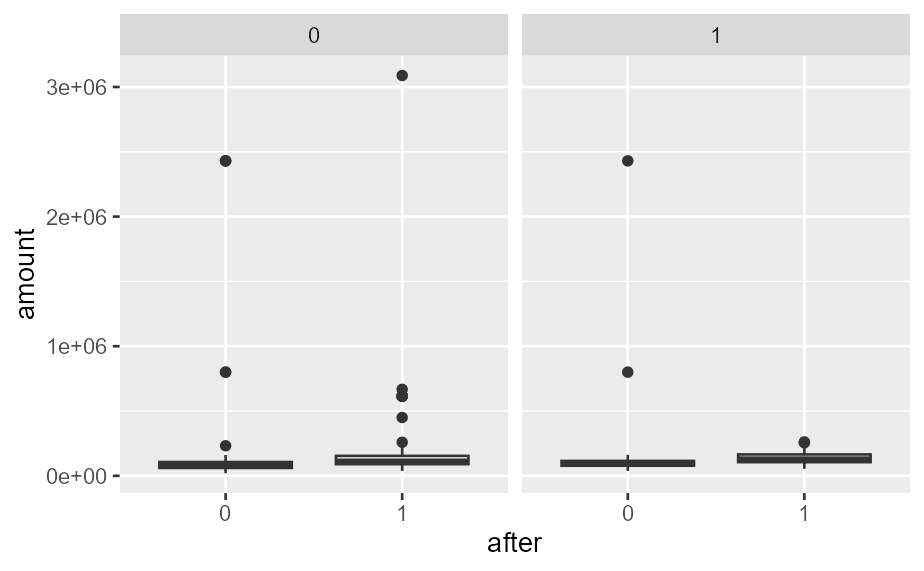

```r
model_data |>
  mutate(treatment = factor(treatment), after = factor(after)) |>
  ggplot(aes(x = after, y = amount)) +
  geom_boxplot() +
  facet_wrap(~treatment)
```

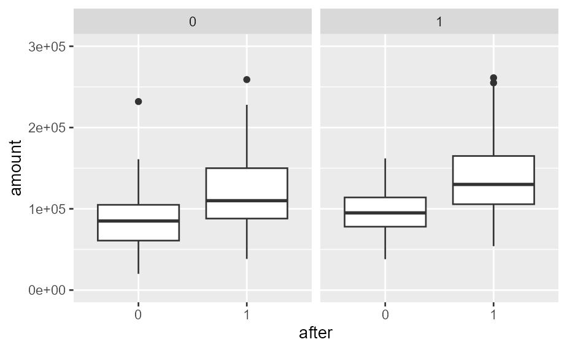

```r
model_data |>
  mutate(treatment = factor(treatment), after = factor(after)) |>
  ggplot(aes(x = after, y = amount)) +
  geom_boxplot() +
  facet_wrap(~treatment) +
  ylim(0, 300000)
```

We could add on some additional predictors to try and better explain the sales amount.

```r
model_data <- model_data |>
  mutate(sale_year = year(ownerdate)) |>
  mutate(age = sale_year - year_built)
```

```r
did_take2 <- lm('amount ~ treatment + after + treatment:after + square_footage + age + building_condition',
                data = model_data)
summary(did_take2)
```

```
Call:
lm(formula = "amount ~ treatment + after + treatment:after + square_footage + age + building_condition",
    data = model_data)

Residuals:
    Min      1Q  Median      3Q     Max
-164695  -53745  -27689    -570 2915212

Coefficients:
                        Estimate Std. Error t value
(Intercept)            147369.07   38570.94   3.821
treatment              -13643.23   24084.81  -0.566
after                   39712.65   25117.53   1.581
square_footage             15.02      22.29   0.674
age                     -1168.66     706.45  -1.654
building_conditionFair -72960.31   93847.83  -0.777
treatment:after         -5120.61   35228.87  -0.145
                       Pr(>|t|)
(Intercept)            0.000146 ***
treatment              0.571268
after                  0.114337
square_footage         0.500627
age                    0.098548 .
building_conditionFair 0.437180
treatment:after        0.884476
---
Signif. codes:
0 ‘***’ 0.001 ‘**’ 0.01 ‘*’ 0.05 ‘.’ 0.1 ‘ ’ 1

Residual standard error: 226300 on 665 degrees of freedom
Multiple R-squared:  0.01219,   Adjusted R-squared:  0.003278
F-statistic: 1.368 on 6 and 665 DF,  p-value: 0.2251
```

No real difference in the conclusions. Notice how on the boxplots, the median values seem to be higher for the treatment group. Perhaps our target is skewed. Let’s now look closer at the target variable.

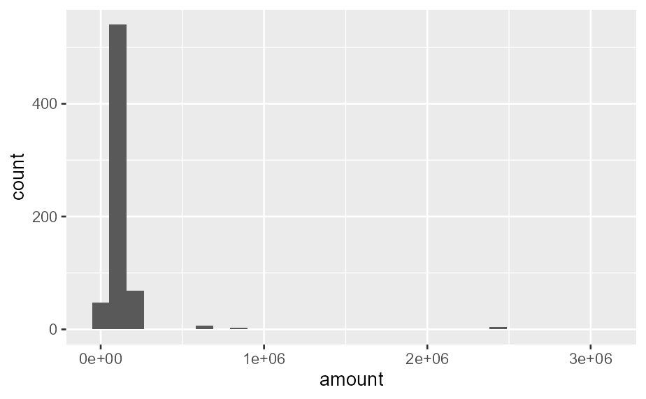

```r
model_data |>
  ggplot(aes(x = amount)) +
  geom_histogram()
```

It looks pretty skewed. Maybe using the log will help reduce the influence of these outliers.

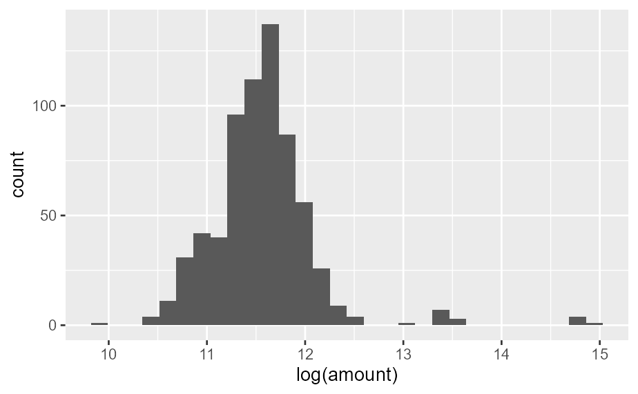

```r
model_data |>
  ggplot(aes(x = log(amount))) +
  geom_histogram()
```

Perhaps we could do better with a logged model. This can reduce the effect of the skew for the target variable. It also allows the model to look for percent increases rather than absolute increases.

```r
did_logged <- lm('log(amount) ~ treatment + after + treatment:after + square_footage + age + building_condition', data = model_data)
summary(did_logged)
```

```
Call:
lm(formula = "log(amount) ~ treatment + after + treatment:after + square_footage + age + building_condition",
    data = model_data)

Residuals:
    Min      1Q  Median      3Q     Max
-1.6226 -0.2546 -0.0031  0.2036  3.4302

Coefficients:
                         Estimate Std. Error t value
(Intercept)             1.123e+01  8.398e-02 133.743
treatment               7.381e-02  5.244e-02   1.407
after                   3.715e-01  5.469e-02   6.794
square_footage          2.179e-04  4.853e-05   4.490
age                    -4.983e-03  1.538e-03  -3.240
building_conditionFair -4.469e-01  2.043e-01  -2.187
treatment:after        -7.171e-03  7.670e-02  -0.093
                       Pr(>|t|)
(Intercept)             < 2e-16 ***
treatment               0.15975
after                  2.42e-11 ***
square_footage         8.40e-06 ***
age                     0.00125 **
building_conditionFair  0.02909 *
treatment:after         0.92554
---
Signif. codes:
0 ‘***’ 0.001 ‘**’ 0.01 ‘*’ 0.05 ‘.’ 0.1 ‘ ’ 1

Residual standard error: 0.4927 on 665 degrees of freedom
Multiple R-squared:  0.1464,    Adjusted R-squared:  0.1387
F-statistic: 19.01 on 6 and 665 DF,  p-value: < 2.2e-16
```

We still get a similar conclusion: the model estimates that the growth in prices was lower for the treatment group, but the difference is not statistically significant. Note too that it estimates that the average sales prices is actually higher for the treatment group now. Let’s visualize what the model is estimating:

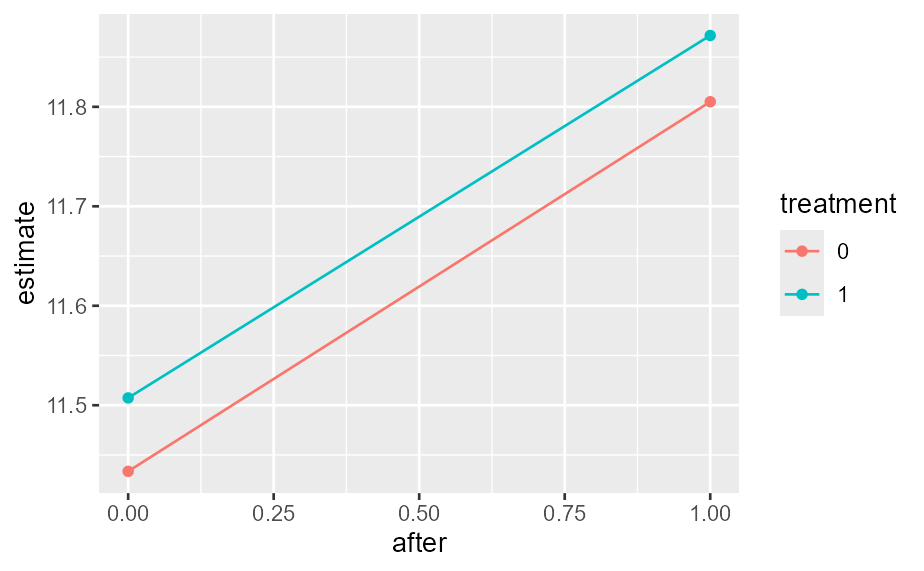

```r
estimates <- tibble(
  square_footage = rep(1500, 4),
  building_condition = rep("Average", 4),
  age = rep(25, 4),
  treatment = c(0, 0, 1, 1),
  after = c(0, 1, 0, 1)
)
estimates <- estimates |>
  mutate(estimate = predict(did_logged, newdata=estimates))
estimates |>
  mutate(treatment = factor(treatment)) |>
  ggplot(aes(x = after, y = estimate, group = treatment, color = treatment)) +
  geom_line() + geom_point()
```

We could compare this to the actual averages:

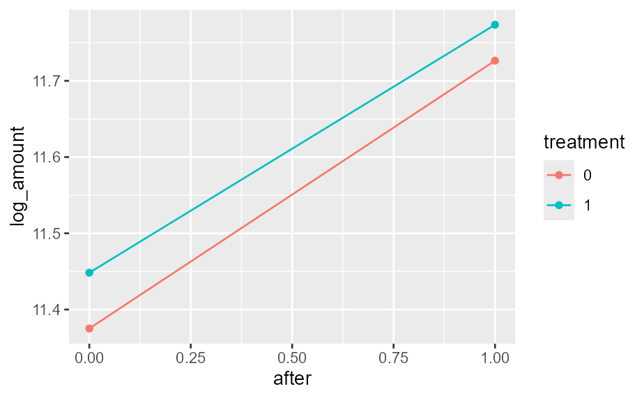

```r
model_data |>
  mutate(treatment = factor(treatment)) |>
  group_by(treatment, after) |>
  summarize(log_amount = mean(log(amount))) |>
  ggplot(aes(x = after, y = log_amount, group = treatment, color = treatment)) +
  geom_line() + geom_point()
```

We could also look at a boxplot:

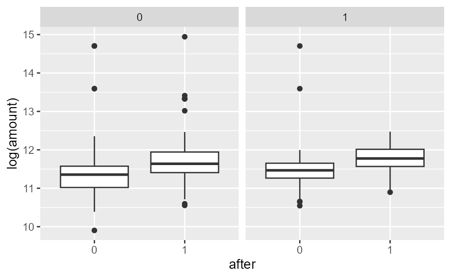

```r
model_data |>
  mutate(treatment = factor(treatment), after = factor(after)) |>
  ggplot(aes(x = after, y = log(amount))) +
  geom_boxplot() +
  facet_wrap(~treatment)
```

What if we want to implement a tpost variable to measure the number of years since the development was placed in service? We can do this by calculating the number of years since the project was place in service. The assumption is that the trend will be different after the development was placed in service, so we can add interaction terms to allow for this difference.

```r
did_logged_tpost <- lm(
  glue('log(amount) ~ treatment  + I(sale_year - {project$YR_PIS})  + treatment:after +  treatment:after:I(sale_year - {project$YR_PIS}) + square_footage + age + building_condition'),
  data = model_data
  )
summary(did_logged_tpost)
```

```
Call:
lm(formula = glue("log(amount) ~ treatment  + I(sale_year - {project$YR_PIS})  + treatment:after +  treatment:after:I(sale_year - {project$YR_PIS}) + square_footage + age + building_condition"),
    data = model_data)

Residuals:
    Min      1Q  Median      3Q     Max
-1.6006 -0.2467  0.0217  0.2019  3.4611

Coefficients:
                                      Estimate Std. Error
(Intercept)                          1.144e+01  8.333e-02
treatment                            3.422e-02  5.054e-02
I(sale_year - 2013)                  3.902e-02  6.601e-03
square_footage                       2.231e-04  4.819e-05
age                                 -5.366e-03  1.531e-03
building_conditionFair              -4.559e-01  2.028e-01
treatment:after                     -2.393e-01  1.086e-01
treatment:I(sale_year - 2013):after  9.861e-02  2.892e-02
                                    t value Pr(>|t|)
(Intercept)                         137.334  < 2e-16 ***
treatment                             0.677 0.498594
I(sale_year - 2013)                   5.912 5.42e-09 ***
square_footage                        4.630 4.40e-06 ***
age                                  -3.504 0.000489 ***
building_conditionFair               -2.248 0.024900 *
treatment:after                      -2.204 0.027864 *
treatment:I(sale_year - 2013):after   3.410 0.000690 ***
---
Signif. codes:
0 ‘***’ 0.001 ‘**’ 0.01 ‘*’ 0.05 ‘.’ 0.1 ‘ ’ 1

Residual standard error: 0.4891 on 664 degrees of freedom
Multiple R-squared:  0.1601,    Adjusted R-squared:  0.1513
F-statistic: 18.08 on 7 and 664 DF,  p-value: < 2.2e-16
```

Let’s visualize the results. Note that we need to select values for the square footage, age, and building condition.

```r
yr_range = min(model_data$sale_year):max(model_data$sale_year)
control_pred <- tibble(
  sale_year = yr_range,
  square_footage = rep(median(model_data$square_footage), length(yr_range)),
  building_condition = rep("Average", length(yr_range)),
  age = rep(median(model_data$age), length(yr_range)),
  treatment = rep(0, length(yr_range)),
  ) |>
  mutate(after = if_else(sale_year < 2013, 0, 1))
control_pred <- control_pred |>
  mutate(estimate = predict(did_logged_tpost, newdata=control_pred))
treatment_pred <- tibble(
  sale_year = yr_range,
  square_footage = rep(median(model_data$square_footage), length(yr_range)),
  building_condition = rep("Average", length(yr_range)),
  age = rep(median(model_data$age), length(yr_range)),
  treatment = rep(1, length(yr_range)),
  ) |>
  mutate(after = if_else(sale_year < 2013, 0, 1))
treatment_pred <- treatment_pred |>
  mutate(estimate = predict(did_logged_tpost, newdata=treatment_pred))

estimate_df <- bind_rows(list("control" = control_pred, "treatment" = treatment_pred), .id = 'group')
```

```r
estimate_df |>
  ggplot(aes(x = sale_year, y = estimate, group = group, color = group)) +
  geom_line() + geom_point() +
  geom_vline(xintercept = project$YR_PIS) + geom_vline(xintercept = project$YR_ALLOC)
```

[output not shown]

Let’s plot this against the actual averages.

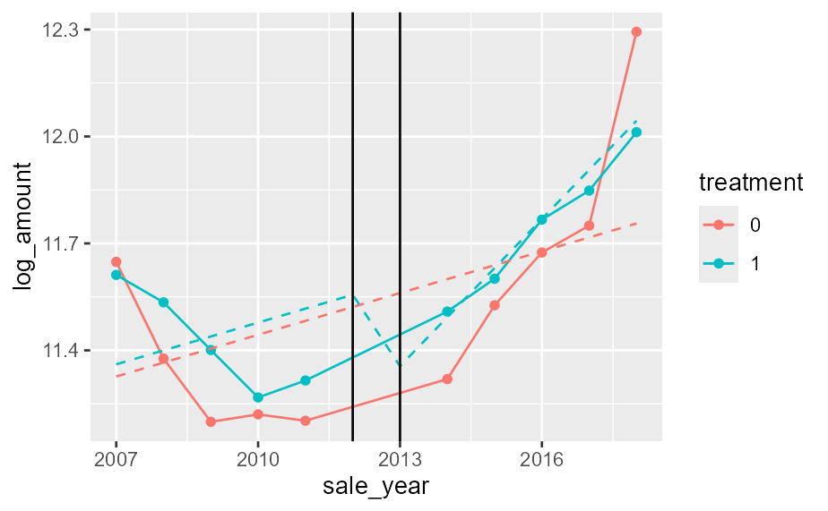

```r
model_data |>
  mutate(treatment = factor(treatment)) |>
  group_by(treatment, sale_year) |>
  summarize(log_amount = mean(log(amount))) |>
  ggplot(aes(x = sale_year, y = log_amount, group = treatment, color = treatment)) +
  geom_line() + geom_point() +
  geom_line(data = estimate_df |> mutate(treatment = factor(treatment)),
            aes(x = sale_year, y = estimate, group = treatment, color = treatment), linetype = 'dashed') +
  geom_vline(xintercept = project$YR_PIS) + geom_vline(xintercept = project$YR_ALLOC)
```

It doesn’t appear that a linear trend really captures what happened. Perhaps we could try a quadratic term. Again, we’ll include interaction terms to allow for the overall trend to change after the development was placed in service.

```r
did_logged_tpost <- lm(glue('log(amount) ~ treatment  + I(sale_year - {project$YR_PIS}) + I((sale_year - {project$YR_PIS})^2) + treatment:after + treatment:after:(I(sale_year - {project$YR_PIS}) + I((sale_year - {project$YR_PIS})^2)) + square_footage + age + building_condition'), data = model_data)
summary(did_logged_tpost)
```

```
Call:
lm(formula = glue("log(amount) ~ treatment  + I(sale_year - {project$YR_PIS}) + I((sale_year - {project$YR_PIS})^2) + treatment:after + treatment:after:(I(sale_year - {project$YR_PIS}) + I((sale_year - {project$YR_PIS})^2)) + square_footage + age + building_condition"),
    data = model_data)

Residuals:
    Min      1Q  Median      3Q     Max
-1.7867 -0.2397 -0.0004  0.1767  3.2272

Coefficients:
                                          Estimate
(Intercept)                              1.117e+01
treatment                                8.775e-02
I(sale_year - 2013)                      7.958e-02
I((sale_year - 2013)^2)                  2.150e-02
square_footage                           1.794e-04
age                                     -4.625e-03
building_conditionFair                  -2.839e-01
treatment:after                          4.370e-03
treatment:I(sale_year - 2013):after      7.246e-02
treatment:I((sale_year - 2013)^2):after -2.411e-02
                                        Std. Error
(Intercept)                              8.088e-02
treatment                                4.684e-02
I(sale_year - 2013)                      7.123e-03
I((sale_year - 2013)^2)                  1.964e-03
square_footage                           4.466e-05
age                                      1.415e-03
building_conditionFair                   1.876e-01
treatment:after                          1.919e-01
treatment:I(sale_year - 2013):after      1.389e-01
treatment:I((sale_year - 2013)^2):after  2.229e-02
                                        t value Pr(>|t|)
(Intercept)                             138.056  < 2e-16
treatment                                 1.873  0.06144
I(sale_year - 2013)                      11.172  < 2e-16
I((sale_year - 2013)^2)                  10.945  < 2e-16
square_footage                            4.018 6.55e-05
age                                      -3.269  0.00113
building_conditionFair                   -1.514  0.13056
treatment:after                           0.023  0.98184
treatment:I(sale_year - 2013):after       0.521  0.60222
treatment:I((sale_year - 2013)^2):after  -1.082  0.27980

(Intercept)                             ***
treatment                               .
I(sale_year - 2013)                     ***
I((sale_year - 2013)^2)                 ***
square_footage                          ***
age                                     **
building_conditionFair
treatment:after
treatment:I(sale_year - 2013):after
treatment:I((sale_year - 2013)^2):after
---
Signif. codes:
0 ‘***’ 0.001 ‘**’ 0.01 ‘*’ 0.05 ‘.’ 0.1 ‘ ’ 1

Residual standard error: 0.4508 on 662 degrees of freedom
Multiple R-squared:  0.2888,    Adjusted R-squared:  0.2792
F-statistic: 29.87 on 9 and 662 DF,  p-value: < 2.2e-16
```

Let’s generate some estimates

```r
yr_range = min(model_data$sale_year):max(model_data$sale_year)
control_pred <- tibble(
  sale_year = yr_range,
  square_footage = rep(median(model_data$square_footage), length(yr_range)),
  building_condition = rep("Average", length(yr_range)),
  age = rep(median(model_data$age), length(yr_range)),
  treatment = rep(0, length(yr_range)),
  ) |>
  mutate(after = if_else(sale_year < project$YR_PIS, 0, 1))
control_pred <- control_pred |>
  bind_cols(predict(did_logged_tpost, newdata=control_pred, interval = "confidence") |> as_tibble())
treatment_pred <- tibble(
  sale_year = yr_range,
  square_footage = rep(median(model_data$square_footage), length(yr_range)),
  building_condition = rep("Average", length(yr_range)),
  age = rep(median(model_data$age), length(yr_range)),
  treatment = rep(1, length(yr_range)),
  ) |>
  mutate(after = if_else(sale_year < project$YR_PIS, 0, 1))
treatment_pred <- treatment_pred |>
  bind_cols(predict(did_logged_tpost, newdata=treatment_pred, interval = "confidence") |> as_tibble())
estimate_df <- bind_rows(list("control" = control_pred, "treatment" = treatment_pred), .id = 'group')
```

Let’s see if this seems to describe the actual data better.

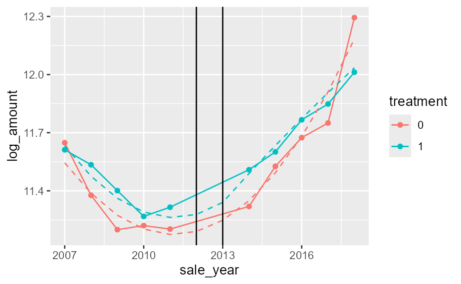

```r
model_data |>
  mutate(treatment = factor(treatment)) |>
  group_by(treatment, sale_year) |>
  summarize(log_amount = mean(log(amount))) |>
  ggplot(aes(x = sale_year, y = log_amount, group = treatment, color = treatment)) +
  geom_line() + geom_point() +
  geom_line(data = estimate_df |> mutate(treatment = factor(treatment)),
            aes(x = sale_year, y = fit, group = treatment, color = treatment), linetype = 'dashed') +
  geom_vline(xintercept = project$YR_PIS) + geom_vline(xintercept = project$YR_ALLOC)
```

I can run an anova to see if the new terms are statistically significant.

```r
reduced_model <- lm(glue('log(amount) ~ treatment  + I(sale_year - {project$YR_PIS}) + I((sale_year - {project$YR_PIS})^2) + square_footage + age + building_condition'), data = model_data)
anova(reduced_model, did_logged_tpost)
```

```
Analysis of Variance Table

Model 1: log(amount) ~ treatment + I(sale_year - 2013) + I((sale_year -
    2013)^2) + square_footage + age + building_condition
Model 2: log(amount) ~ treatment + I(sale_year - 2013) + I((sale_year -
    2013)^2) + treatment:after + treatment:after:(I(sale_year -
    2013) + I((sale_year - 2013)^2)) + square_footage + age +
    building_condition
  Res.Df    RSS Df Sum of Sq      F  Pr(>F)
1    665 135.93
2    662 134.51  3    1.4213 2.3318 0.07306 .
---
Signif. codes:
0 ‘***’ 0.001 ‘**’ 0.01 ‘*’ 0.05 ‘.’ 0.1 ‘ ’ 1
```

We can also include a confidence interval to estimate whether this trend had a statistically significant difference on the mean. Here, the dashed line continues the trend while the blue shaded area gives a confidence interval for the estimated mean.

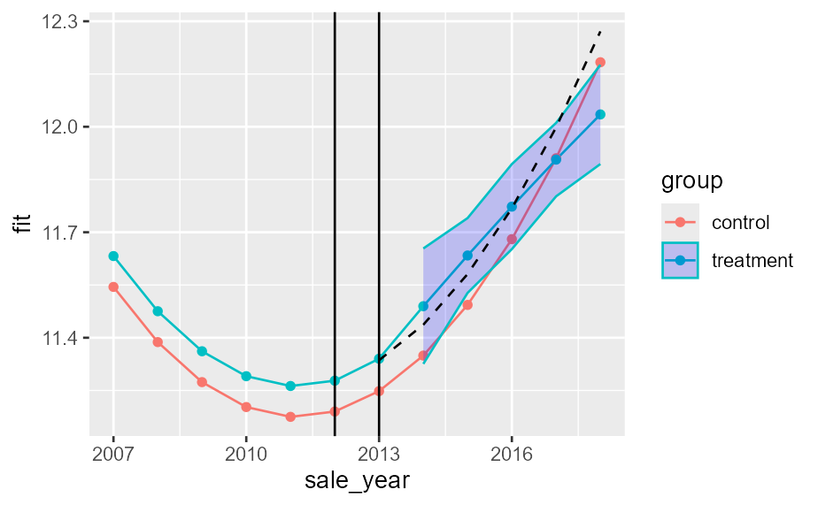

```r
estimate_df |>
  ggplot(aes(x = sale_year, y = fit, group = group, color = group)) +
  geom_line() + geom_point() +
  geom_ribbon(data = estimate_df |> filter(group == "treatment", sale_year > project$YR_PIS), aes(ymin = lwr, ymax = upr), alpha = 0.2, fill = "blue") +
  geom_line(data = estimate_df |>
    filter(group == "control", sale_year >= project$YR_PIS) |>
    mutate(fit = fit + did_logged_tpost$coefficients['treatment']),
    aes(x = sale_year, y = fit), linetype = 'dashed', color = "black") +
  geom_vline(xintercept = project$YR_PIS) + geom_vline(xintercept = project$YR_ALLOC)
```

### Extending to other developments

I can modularize my code into functions so that I can easily check other developments.

```r
get_project_data <- function(hudid){
  project <- LIHTC |>
  filter(HUD_ID == hudid)
  project <- project |>
    select(YR_ALLOC, YR_PIS, lat = LATITUDE, lng = LONGITUDE) |>
    st_as_sf(coords = c("lng", "lat"), crs = 4326)

  # To take care of 8888 or 9999 YR_ALLOC or YR_PIS
  project <- project |>
    mutate(YR_PIS = min(YR_ALLOC, YR_ALLOC + 10)) |>
    mutate(YR_ALLOC = min(YR_ALLOC, YR_PIS))

  return(project)
}
get_model_data <- function(project) {
  sales_details <- sales_details %>%
    mutate(dist = st_distance(home_loc, project$geometry[1])) |>
    mutate(dist = drop_units(dist * 3.28084))

  model_data <- sales_details |>
    filter(dist <= 3000) |>
    filter(year(ownerdate) %in% c(
      (project$YR_ALLOC - 5):(project$YR_ALLOC - 1),
      (project$YR_PIS + 1):(project$YR_PIS + 5)
    )
    )

  model_data <- model_data |>
    mutate(
      treatment = if_else(dist <= 2000, 1, 0),
      after = if_else(year(ownerdate) %in% (project$YR_ALLOC - 5):(project$YR_ALLOC - 1), 0, 1)
      )

  model_data <- model_data |>
    mutate(sale_year = year(ownerdate)) |>
    mutate(age = sale_year - year_built)

  return(model_data)
}
get_estimates <- function(model, model_data, project){

  yr_range = min(model_data$sale_year):max(model_data$sale_year)

  control_pred <- tibble(
    sale_year = yr_range,
    square_footage = rep(median(model_data$square_footage), length(yr_range)),
    building_condition = rep("Average", length(yr_range)),
    age = rep(median(model_data$age), length(yr_range)),
    treatment = rep(0, length(yr_range)),
    ) |>
    mutate(after = if_else(sale_year < project$YR_PIS, 0, 1))

control_pred <- control_pred |>
  bind_cols(predict(model, newdata=control_pred, interval = "confidence") |> as_tibble())

  treatment_pred <- tibble(
    sale_year = yr_range,
    square_footage = rep(median(model_data$square_footage), length(yr_range)),
    building_condition = rep("Average", length(yr_range)),
    age = rep(median(model_data$age), length(yr_range)),
    treatment = rep(1, length(yr_range)),
    ) |>
    mutate(after = if_else(sale_year < project$YR_PIS, 0, 1))

treatment_pred <- treatment_pred |>
  bind_cols(predict(model, newdata=treatment_pred, interval = "confidence") |> as_tibble())

  estimate_df <- bind_rows(list("control" = control_pred, "treatment" = treatment_pred), .id = 'group')

  return(estimate_df)
}
```

Let’s look at a couple of example developments.

```r
hudid <- "TNA20160013"
project <- get_project_data(hudid)
model_data <- get_model_data(project)
did_logged_tpost <- lm(glue('log(amount) ~ treatment  + I(sale_year - {project$YR_PIS}) + I((sale_year - {project$YR_PIS})^2) + treatment:after + treatment:after:(I(sale_year - {project$YR_PIS}) + I((sale_year - {project$YR_PIS})^2)) + square_footage + age + building_condition'), data = model_data)
summary(did_logged_tpost)
```

```
Call:
lm(formula = glue("log(amount) ~ treatment  + I(sale_year - {project$YR_PIS}) + I((sale_year - {project$YR_PIS})^2) + treatment:after + treatment:after:(I(sale_year - {project$YR_PIS}) + I((sale_year - {project$YR_PIS})^2)) + square_footage + age + building_condition"),
    data = model_data)

Residuals:
     Min       1Q   Median       3Q      Max
-0.99105 -0.26871 -0.02366  0.21487  1.93204

Coefficients:
                                          Estimate
(Intercept)                             11.4023533
treatment                               -0.1709683
I(sale_year - 2015)                      0.1326598
I((sale_year - 2015)^2)                  0.0195066
square_footage                           0.0002870
age                                     -0.0057493
building_conditionFair                  -1.0182443
building_conditionPoor                  -0.6193890
treatment:after                          0.0438910
treatment:I(sale_year - 2015):after      0.2165270
treatment:I((sale_year - 2015)^2):after -0.0578294
                                        Std. Error
(Intercept)                              0.1128755
treatment                                0.0899588
I(sale_year - 2015)                      0.0131956
I((sale_year - 2015)^2)                  0.0039709
square_footage                           0.0000669
age                                      0.0014198
building_conditionFair                   0.2272673
building_conditionPoor                   0.3234897
treatment:after                          0.2563692
treatment:I(sale_year - 2015):after      0.1749010
treatment:I((sale_year - 2015)^2):after  0.0281992
                                        t value Pr(>|t|)
(Intercept)                             101.017  < 2e-16
treatment                                -1.901   0.0586
I(sale_year - 2015)                      10.053  < 2e-16
I((sale_year - 2015)^2)                   4.912 1.67e-06
square_footage                            4.290 2.59e-05
age                                      -4.049 6.94e-05
```

[output cut: 9 more lines]

```
I((sale_year - 2015)^2)                 ***
square_footage                          ***
age                                     ***
building_conditionFair                  ***
building_conditionPoor                  .
treatment:after
treatment:I(sale_year - 2015):after
treatment:I((sale_year - 2015)^2):after *
---
Signif. codes:
0 ‘***’ 0.001 ‘**’ 0.01 ‘*’ 0.05 ‘.’ 0.1 ‘ ’ 1

Residual standard error: 0.4397 on 239 degrees of freedom
Multiple R-squared:  0.5818,    Adjusted R-squared:  0.5643
F-statistic: 33.25 on 10 and 239 DF,  p-value: < 2.2e-16
```

```r
reduced_model <- lm(glue('log(amount) ~ treatment  + I(sale_year - {project$YR_PIS}) + I((sale_year - {project$YR_PIS})^2) + square_footage + age + building_condition'), data = model_data)
anova(reduced_model, did_logged_tpost)
```

```
Analysis of Variance Table

Model 1: log(amount) ~ treatment + I(sale_year - 2015) + I((sale_year -
    2015)^2) + square_footage + age + building_condition
Model 2: log(amount) ~ treatment + I(sale_year - 2015) + I((sale_year -
    2015)^2) + treatment:after + treatment:after:(I(sale_year -
    2015) + I((sale_year - 2015)^2)) + square_footage + age +
    building_condition
  Res.Df    RSS Df Sum of Sq      F   Pr(>F)
1    242 48.893
2    239 46.209  3    2.6843 4.6279 0.003631 **
---
Signif. codes:
0 ‘***’ 0.001 ‘**’ 0.01 ‘*’ 0.05 ‘.’ 0.1 ‘ ’ 1
```

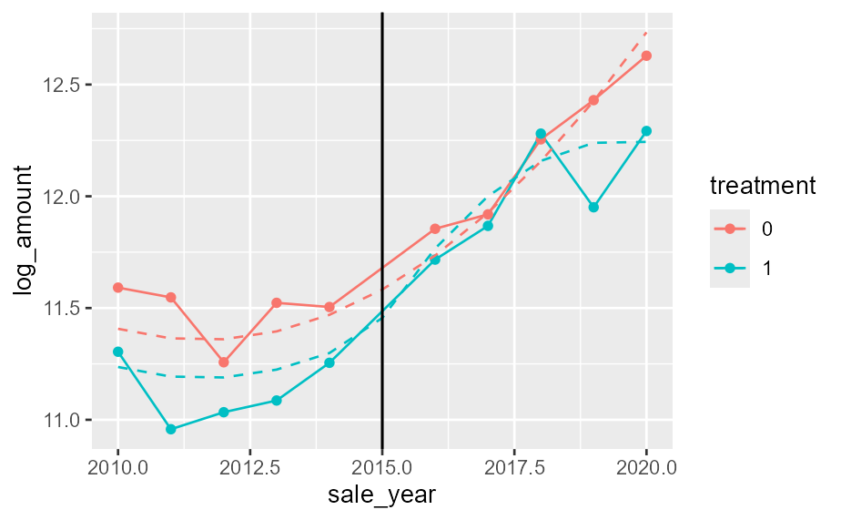

```r
estimate_df <- get_estimates(did_logged_tpost, model_data, project)
model_data |>
  mutate(treatment = factor(treatment)) |>
  group_by(treatment, sale_year) |>
  summarize(log_amount = mean(log(amount))) |>
  ggplot(aes(x = sale_year, y = log_amount, group = treatment, color = treatment)) +
  geom_line() + geom_point() +
  geom_line(data = estimate_df |> mutate(treatment = factor(treatment)),
            aes(x = sale_year, y = fit, group = treatment, color = treatment), linetype = 'dashed') +
  geom_vline(xintercept = project$YR_PIS) + geom_vline(xintercept = project$YR_ALLOC)
```

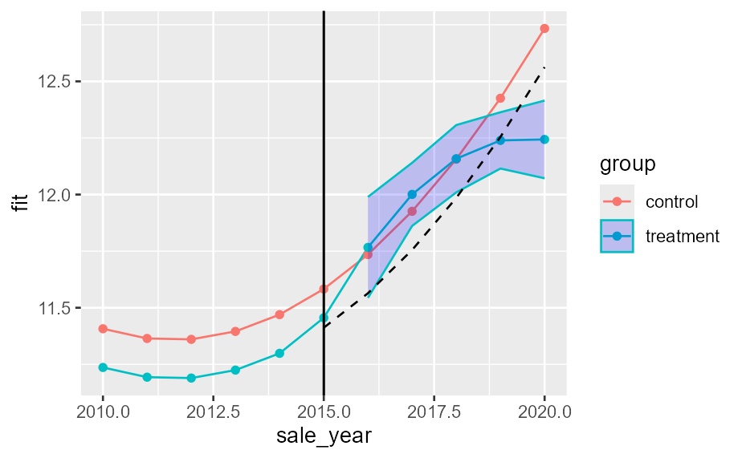

```r
estimate_df |>
  ggplot(aes(x = sale_year, y = fit, group = group, color = group)) +
  geom_line() + geom_point() +
  geom_ribbon(data = estimate_df |> filter(group == "treatment", sale_year > project$YR_PIS), aes(ymin = lwr, ymax = upr), alpha = 0.2, fill = "blue") +
  geom_line(data = estimate_df |>
    filter(group == "control", sale_year >= project$YR_PIS) |>
    mutate(fit = fit + did_logged_tpost$coefficients['treatment']),
    aes(x = sale_year, y = fit), linetype = 'dashed', color = "black") +
  geom_vline(xintercept = project$YR_PIS) + geom_vline(xintercept = project$YR_ALLOC)
```

```r
hudid <- "TNA20110543"
project <- get_project_data(hudid)
model_data <- get_model_data(project)
did_logged_tpost <- lm(glue('log(amount) ~ treatment  + I(sale_year - {project$YR_PIS}) + I((sale_year - {project$YR_PIS})^2) + treatment:after + treatment:after:(I(sale_year - {project$YR_PIS}) + I((sale_year - {project$YR_PIS})^2)) + square_footage + age + building_condition'), data = model_data)
summary(did_logged_tpost)
```

```
Call:
lm(formula = glue("log(amount) ~ treatment  + I(sale_year - {project$YR_PIS}) + I((sale_year - {project$YR_PIS})^2) + treatment:after + treatment:after:(I(sale_year - {project$YR_PIS}) + I((sale_year - {project$YR_PIS})^2)) + square_footage + age + building_condition"),
    data = model_data)

Residuals:
    Min      1Q  Median      3Q     Max
-2.2657 -0.2148  0.0704  0.2262  2.3108

Coefficients:
                                          Estimate
(Intercept)                              1.110e+01
treatment                               -3.947e-02
I(sale_year - 2008)                      7.721e-04
I((sale_year - 2008)^2)                 -9.644e-03
square_footage                           4.574e-04
age                                     -5.443e-03
building_conditionFair                  -1.972e-01
building_conditionPoor                  -2.559e-01
treatment:after                         -4.903e-01
treatment:I(sale_year - 2008):after      1.499e-01
treatment:I((sale_year - 2008)^2):after -1.673e-02
                                        Std. Error
(Intercept)                              7.427e-02
treatment                                4.240e-02
I(sale_year - 2008)                      5.821e-03
I((sale_year - 2008)^2)                  1.921e-03
square_footage                           4.143e-05
age                                      6.892e-04
building_conditionFair                   8.371e-02
building_conditionPoor                   2.180e-01
treatment:after                          1.792e-01
treatment:I(sale_year - 2008):after      1.420e-01
treatment:I((sale_year - 2008)^2):after  2.389e-02
                                        t value Pr(>|t|)
(Intercept)                             149.481  < 2e-16
treatment                                -0.931  0.35225
I(sale_year - 2008)                       0.133  0.89452
I((sale_year - 2008)^2)                  -5.020 6.84e-07
square_footage                           11.039  < 2e-16
age                                      -7.897 1.38e-14
```

[output cut: 9 more lines]

```
I((sale_year - 2008)^2)                 ***
square_footage                          ***
age                                     ***
building_conditionFair                  *
building_conditionPoor
treatment:after                         **
treatment:I(sale_year - 2008):after
treatment:I((sale_year - 2008)^2):after
---
Signif. codes:
0 ‘***’ 0.001 ‘**’ 0.01 ‘*’ 0.05 ‘.’ 0.1 ‘ ’ 1

Residual standard error: 0.3755 on 598 degrees of freedom
Multiple R-squared:  0.366, Adjusted R-squared:  0.3554
F-statistic: 34.52 on 10 and 598 DF,  p-value: < 2.2e-16
```

```r
reduced_model <- lm(glue('log(amount) ~ treatment  + I(sale_year - {project$YR_PIS}) + I((sale_year - {project$YR_PIS})^2) + square_footage + age + building_condition'), data = model_data)
anova(reduced_model, did_logged_tpost)
```

```
Analysis of Variance Table

Model 1: log(amount) ~ treatment + I(sale_year - 2008) + I((sale_year -
    2008)^2) + square_footage + age + building_condition
Model 2: log(amount) ~ treatment + I(sale_year - 2008) + I((sale_year -
    2008)^2) + treatment:after + treatment:after:(I(sale_year -
    2008) + I((sale_year - 2008)^2)) + square_footage + age +
    building_condition
  Res.Df    RSS Df Sum of Sq      F    Pr(>F)
1    601 87.204
2    598 84.314  3    2.8901 6.8328 0.0001564 ***
---
Signif. codes:
0 ‘***’ 0.001 ‘**’ 0.01 ‘*’ 0.05 ‘.’ 0.1 ‘ ’ 1
```

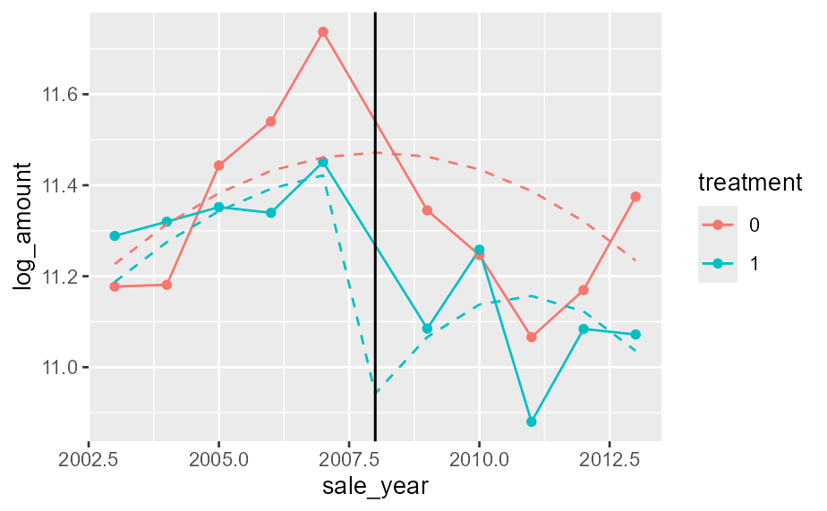

```r
estimate_df <- get_estimates(did_logged_tpost, model_data, project)
model_data |>
  mutate(treatment = factor(treatment)) |>
  group_by(treatment, sale_year) |>
  summarize(log_amount = mean(log(amount))) |>
  ggplot(aes(x = sale_year, y = log_amount, group = treatment, color = treatment)) +
  geom_line() + geom_point() +
  geom_line(data = estimate_df |> mutate(treatment = factor(treatment)),
            aes(x = sale_year, y = fit, group = treatment, color = treatment), linetype = 'dashed') +
  geom_vline(xintercept = project$YR_PIS) + geom_vline(xintercept = project$YR_ALLOC)
```

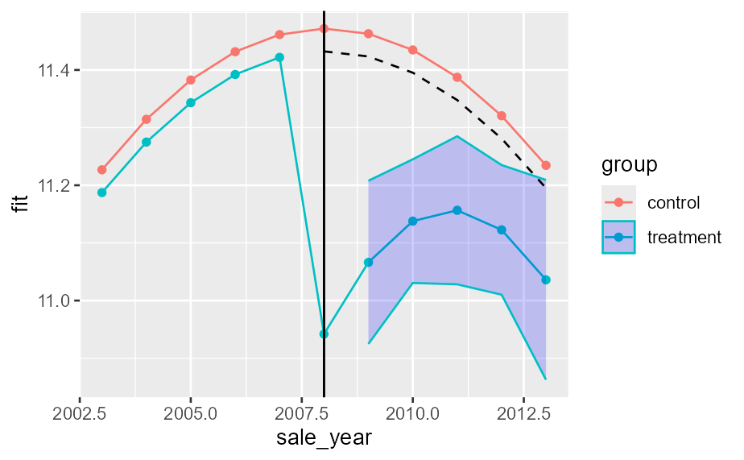

```r
estimate_df |>
  ggplot(aes(x = sale_year, y = fit, group = group, color = group)) +
  geom_line() + geom_point() +
  geom_ribbon(data = estimate_df |> filter(group == "treatment", sale_year > project$YR_PIS), aes(ymin = lwr, ymax = upr), alpha = 0.2, fill = "blue") +
  geom_line(data = estimate_df |>
    filter(group == "control", sale_year >= project$YR_PIS) |>
    mutate(fit = fit + did_logged_tpost$coefficients['treatment']),
    aes(x = sale_year, y = fit), linetype = 'dashed', color = "black") +
  geom_vline(xintercept = project$YR_PIS) + geom_vline(xintercept = project$YR_ALLOC)
```